[figure not shown]

# NAZRUG : Interacting with Databases Using R

Compiled on 2016-03-04 07:38:12 by LMcCoy using R version 3.2.2 (2015-08-14)

This guide was created by:  
**Lee McCoy** and **Jodi Norris**  
Southern Colorado Plateau Network  
Inventory and Monitoring Program  
National Park Service, Flagstaff, AZ

This guide outlines a few ways to interact with Microsoft Access, SQL Server, and ESRI Geodatabases from R.

Load the dplyr package because it is awesome - see last months presentation by Derek Sonderegger. (However, it isn’t necessary for interacting with DBs)

```r
library(dplyr)
```

# 1 RODBC Package

The RODBC package provides the tools to interact with data in databases using an ODBC connection. ODBC provides an open, vendor- neutral way of accessing data stored in a variety of proprietary databases.

Install RODBC package if you haven’t previously.

```r
install.packages("RODBC")
```

Load the RODBC package.

```r
library(RODBC)
```

NOTE: For RODBC to work, both R and the database need to be using the same bit version (32-bit, 64-bit)(i.e. if you are running 32-bit Access, you need to use 32-bit R). You can change which version of R you are running by going to Tools > Global Options…

[figure not shown]

[figure not shown]

# 2 Databases

In order to use a database, we need to form a connection. This tells R the type of database and how to interact with this database.

View available ODBC data sources.

```r
odbcDataSources()
```

```
##                                              dBASE Files
##    "Microsoft Access dBASE Driver (*.dbf, *.ndx, *.mdx)"
##                                              Excel Files
## "Microsoft Excel Driver (*.xls, *.xlsx, *.xlsm, *.xlsb)"
##                                       MS Access Database
##               "Microsoft Access Driver (*.mdb, *.accdb)"
##                                   Visio Database Samples
##               "Microsoft Access Driver (*.mdb, *.accdb)"
##                              MasterPlantDB_INPSCPN020019
##                          "SQL Server Native Client 10.0"
```

# 3 Access

Set the database location.

```r
accessdb <- "C:\\NAZRUG\\MikeGarage.accdb"
```

## 3.1 Connect to the Access database

see what type of connections are possible.

```r
?odbcConnect  #several different defined types of connections
```

Using odbcConnectAccess2007().

```r
#create a connection to the access db
accesscon <- odbcConnectAccess2007(accessdb)

#review the connection
accesscon
```

```
## RODBC Connection 1
## Details:
##   case=nochange
##   DBQ=C:\NAZRUG\MikeGarage.accdb
##   Driver={Microsoft Access Driver (*.mdb, *.accdb)}
##   DriverId=25
##   FIL=MS Access
##   MaxBufferSize=2048
##   PageTimeout=5
##   UID=admin
```

```r
odbcGetInfo(accesscon)
```

```
##                          DBMS_Name                           DBMS_Ver
##                           "ACCESS"                       "12.00.0000"
##                    Driver_ODBC_Ver                   Data_Source_Name
##                            "03.51"                                 ""
##                        Driver_Name                         Driver_Ver
##                      "ACEODBC.DLL" "Microsoft Access database engine"
##                           ODBC_Ver                        Server_Name
##                       "03.80.0000"                           "ACCESS"
```

```r
class(accesscon)
```

```
## [1] "RODBC"
```

```r
#As long as the connection is open, communication can occur between R and the database.  It is safest to open a connection, perform database tasks, and close immediately to keep from having floating connections.

#I can't find a way to determine if a connection is still open

#close the connection to the access db - this terminates all communication between R and the database
close(accesscon)
```

## 3.2 Retrieve the DB structure

Open a connection to the Access database and get table names.

Using sqlTables().

```r
#open an odbc connection
accesscon <- odbcConnectAccess2007(accessdb)
  #report all tables (regardless of type)
    allaccesstables <- sqlTables(accesscon)
    allaccesstables
```

```
##                       TABLE_CAT TABLE_SCHEM                 TABLE_NAME
## 1  C:\\NAZRUG\\MikeGarage.accdb        <NA>          MSysAccessStorage
## 2  C:\\NAZRUG\\MikeGarage.accdb        <NA>              MSysAccessXML
## 3  C:\\NAZRUG\\MikeGarage.accdb        <NA>                   MSysACEs
## 4  C:\\NAZRUG\\MikeGarage.accdb        <NA>         MSysComplexColumns
## 5  C:\\NAZRUG\\MikeGarage.accdb        <NA>                MSysNameMap
## 6  C:\\NAZRUG\\MikeGarage.accdb        <NA> MSysNavPaneGroupCategories
## 7  C:\\NAZRUG\\MikeGarage.accdb        <NA>          MSysNavPaneGroups
## 8  C:\\NAZRUG\\MikeGarage.accdb        <NA>  MSysNavPaneGroupToObjects
## 9  C:\\NAZRUG\\MikeGarage.accdb        <NA>       MSysNavPaneObjectIDs
## 10 C:\\NAZRUG\\MikeGarage.accdb        <NA>                MSysObjects
## 11 C:\\NAZRUG\\MikeGarage.accdb        <NA>                MSysQueries
## 12 C:\\NAZRUG\\MikeGarage.accdb        <NA>          MSysRelationships
## 13 C:\\NAZRUG\\MikeGarage.accdb        <NA>              MSysResources
## 14 C:\\NAZRUG\\MikeGarage.accdb        <NA>                  Customers
```

[output cut: 27 more lines]

```r
  # report only the data tables
    dbaccesstables <- sqlTables(accesscon, tableType = "TABLE")
    dbaccesstables
```

```
##                      TABLE_CAT TABLE_SCHEM     TABLE_NAME TABLE_TYPE
## 1 C:\\NAZRUG\\MikeGarage.accdb        <NA>      Customers      TABLE
## 2 C:\\NAZRUG\\MikeGarage.accdb        <NA>       Employee      TABLE
## 3 C:\\NAZRUG\\MikeGarage.accdb        <NA>        Invoice      TABLE
## 4 C:\\NAZRUG\\MikeGarage.accdb        <NA> InvoiceDetails      TABLE
## 5 C:\\NAZRUG\\MikeGarage.accdb        <NA>          Parts      TABLE
## 6 C:\\NAZRUG\\MikeGarage.accdb        <NA>      Suppliers      TABLE
## 7 C:\\NAZRUG\\MikeGarage.accdb        <NA>       Vehicles      TABLE
##   REMARKS
## 1    <NA>
## 2    <NA>
## 3    <NA>
## 4    <NA>
## 5    <NA>
## 6    <NA>
## 7    <NA>
```

```r
  #report only the system tables
    sysaccesstables <- sqlTables(accesscon, tableType = "SYSTEM TABLE")
    sysaccesstables
```

```
##                       TABLE_CAT TABLE_SCHEM                 TABLE_NAME
## 1  C:\\NAZRUG\\MikeGarage.accdb        <NA>          MSysAccessStorage
## 2  C:\\NAZRUG\\MikeGarage.accdb        <NA>              MSysAccessXML
## 3  C:\\NAZRUG\\MikeGarage.accdb        <NA>                   MSysACEs
## 4  C:\\NAZRUG\\MikeGarage.accdb        <NA>         MSysComplexColumns
## 5  C:\\NAZRUG\\MikeGarage.accdb        <NA>                MSysNameMap
## 6  C:\\NAZRUG\\MikeGarage.accdb        <NA> MSysNavPaneGroupCategories
## 7  C:\\NAZRUG\\MikeGarage.accdb        <NA>          MSysNavPaneGroups
## 8  C:\\NAZRUG\\MikeGarage.accdb        <NA>  MSysNavPaneGroupToObjects
## 9  C:\\NAZRUG\\MikeGarage.accdb        <NA>       MSysNavPaneObjectIDs
## 10 C:\\NAZRUG\\MikeGarage.accdb        <NA>                MSysObjects
## 11 C:\\NAZRUG\\MikeGarage.accdb        <NA>                MSysQueries
## 12 C:\\NAZRUG\\MikeGarage.accdb        <NA>          MSysRelationships
## 13 C:\\NAZRUG\\MikeGarage.accdb        <NA>              MSysResources
##      TABLE_TYPE REMARKS
## 1  SYSTEM TABLE    <NA>
## 2  SYSTEM TABLE    <NA>
## 3  SYSTEM TABLE    <NA>
## 4  SYSTEM TABLE    <NA>
## 5  SYSTEM TABLE    <NA>
## 6  SYSTEM TABLE    <NA>
## 7  SYSTEM TABLE    <NA>
## 8  SYSTEM TABLE    <NA>
## 9  SYSTEM TABLE    <NA>
## 10 SYSTEM TABLE    <NA>
## 11 SYSTEM TABLE    <NA>
## 12 SYSTEM TABLE    <NA>
## 13 SYSTEM TABLE    <NA>
```

```r
#close the odbc connection
close(accesscon)
```

## 3.3 Retrieve the structure of a specific table

Using sqlColumns().

```r
#open an odbc connection
accesscon <- odbcConnectAccess2007(accessdb)
  #get all columns for a specific table
    tablecolumns <- sqlColumns(accesscon, "Parts")
close(accesscon)

#subset the output to make it easier to see
tablecolumns %>%
  select(TABLE_NAME, COLUMN_NAME, TYPE_NAME, COLUMN_SIZE, IS_NULLABLE, REMARKS)
```

```
##   TABLE_NAME     COLUMN_NAME TYPE_NAME COLUMN_SIZE IS_NULLABLE
## 1      Parts     Part number   VARCHAR         255         YES
## 2      Parts       Part name   VARCHAR         255         YES
## 3      Parts            Cost  CURRENCY          19         YES
## 4      Parts      Sell price  CURRENCY          19         YES
## 5      Parts        Supplier   INTEGER          10         YES
## 6      Parts    Qty in stock      REAL          24         YES
## 7      Parts Last order date  DATETIME          19         YES
##                                     REMARKS
## 1 8 digit internal part number  (###-#####)
## 2     Standard text description of the part
## 3              Our cost at time of purchase
## 4        The amount we charge for this part
## 5                     Pk for Supplier table
## 6                   Number of units on hand
## 7                                      <NA>
```

## 3.4 Retrieve a single table

Using sqlFetch().

```r
accesscon <- odbcConnectAccess2007(accessdb)
    vehicles <- sqlFetch(accesscon, "Vehicles")
close(accesscon)

vehicles
```

```
##   Vehicle ID          VIN Owner     Make      Model Model Year  Model type
## 1    ABCD123   V123445XYZ     1    Dodge    Caravan       2005         Van
## 2    DRSally  X78656Y654Z     2 Mercedes       G500       2008         SUV
## 3    Sally01 V62626262ABC     2     Ford Mustang GT       2006 Convertible
##   Color
## 1  Blue
## 2 Black
## 3   Red
```

## 3.5 Retrieve a single table using a SQL query

Using sqlQuery().

```r
accesscon <- odbcConnectAccess2007(accessdb)
  vehicles <- sqlQuery(accesscon, "SELECT * FROM Vehicles")
close(accesscon)

vehicles
```

```
##   Vehicle ID          VIN Owner     Make      Model Model Year  Model type
## 1    ABCD123   V123445XYZ     1    Dodge    Caravan       2005         Van
## 2    DRSally  X78656Y654Z     2 Mercedes       G500       2008         SUV
## 3    Sally01 V62626262ABC     2     Ford Mustang GT       2006 Convertible
##   Color
## 1  Blue
## 2 Black
## 3   Red
```

## 3.6 Use a SQL query to retrieve data across multiple tables

Using sqlQuery().

```r
accesscon <- odbcConnectAccess2007(accessdb)
  customervehicles <- sqlQuery(accesscon, "SELECT Customers.[First Name], Customers.[Last Name],
                              Vehicles.Make, Vehicles.Model FROM Customers INNER JOIN Vehicles ON
                              Customers.ID = Vehicles.Owner;")
close(accesscon)

customervehicles
```

```
##   First Name Last Name     Make      Model
## 1      Marty      Last    Dodge    Caravan
## 2      Sally     First Mercedes       G500
## 3      Sally     First     Ford Mustang GT
```

## 3.7 Creating a new table

Using sqlSave().

```r
#create a new data frame
hotrod = data.frame(Type = "Pickup", SubType = "Stepside", Year = 1969, Make = "Chevy", Model = "C/K 10", Color = "Yellow")

accesscon <- odbcConnectAccess2007(accessdb)
  sqlSave(accesscon, hotrod, tablename = "Hotrod", append = F, rownames = "ID", addPK = T)
close(accesscon)
```

## 3.8 Append data to an existing table

Using sqlSave().

```r
#create a new data frame
hotrod = data.frame(ID = 2, Type = "Car", SubType = NA, Year = 1974, Make = "Plymouth", Model = "Gold Duster", Color = "Cream")

accesscon <- odbcConnectAccess2007(accessdb)
 sqlSave(accesscon, hotrod, tablename = "Hotrod", append = TRUE, rownames=F)
close(accesscon)
```

## 3.9 A few notes

sqlFetch and sqlQuery allows as.is = T/F. The meaning of “as.is” can be counterintuitive. On import, all fields are initially assumed to be character strings. During import these are converted to a datatype based on the contents of the column. One might assume that adding “as.is = T” would result in each column being the same type as it was in the original database. Instead, “as.is = T” results in all of the columns being left as character strings. “as.is = F” results in each column being analyzed and changed into an appropriate datatype. “as.is = F” is the default, so you don’t even need to include it!

## 3.10 stringsAsFactors = F keeps R from converting character strings to factors, which it really likes to do.

# 4 SQL Server

There are several ways to connect to a SQL Server DB. The main difference is whether you have SQL Server installed on your local machine. The driver is then provided by SQL Server. If SQL Server is not installed on your local machine, you will need to create a named connection (see end of this file for information on creating a named connection).

## 4.1 Connect to the SQL Server database

Using odbcDriverConnect(). Specify driver, server, and database or create a named connection. Here are the three different connection types.

```r
#create a connection to a SQL Server DB on the local machine
  sqlcon <- odbcDriverConnect("driver=SQL Server Native Client 10.0; server=INPSCPN020011\\SQLEXPRESS; database=ITIS; trusted_connection=yes;")
#create a connection to a SQL Server DB on a server - this will only work if I am connected to the server
  sqlcon2 <- odbcDriverConnect("driver=SQL Server Native Client 10.0; server=INPSCPNMS01\\SQLEXPRESS; database=Demo; trusted_connection=yes;")
#create a connection using a named connection (see end of this file for information on creating a named connection) - this will only work if I am connected to the server
  sqlcon3 <- odbcConnect("MasterPlantDB_INPSCPN020019")

#review the connection
sqlcon
```

```
## RODBC Connection 9
## Details:
##   case=nochange
##   DRIVER=SQL Server Native Client 10.0
##   SERVER=INPSCPN020011\SQLEXPRESS
##   UID=
##   Trusted_Connection=yes
##   WSID=INPSCPN020011
##   DATABASE=ITIS
```

```r
odbcGetInfo(sqlcon)
```

```
##                   DBMS_Name                    DBMS_Ver
##      "Microsoft SQL Server"                "10.50.4042"
##             Driver_ODBC_Ver            Data_Source_Name
##                     "03.52"                          ""
##                 Driver_Name                  Driver_Ver
##             "sqlncli10.dll"                "10.50.4042"
##                    ODBC_Ver                 Server_Name
##                "03.80.0000" "INPSCPN020011\\SQLEXPRESS"
```

```r
class(sqlcon)
```

```
## [1] "RODBC"
```

```r
#As long as the connection is open, communication can occur between R and the database.  It is safest to open a connection, perform database tasks, and close immediately to keep from having floating connections.

#I can't find a way to determine if a connection is still open

#close the connection to the access db - this terminates all communication between R and the database
close(sqlcon)
close(sqlcon2)
close(sqlcon3)
```

## 4.2 Retrieve the DB structure

Open a connection to the sql database and get the names of tables.

Using sqlTables().

```r
#open an odbc connection
sqlcon <- odbcDriverConnect("driver=SQL Server Native Client 10.0; server=INPSCPN020011\\SQLEXPRESS; database=ITIS; trusted_connection=yes;")
  #get all table types
    allsqltables <- sqlTables(sqlcon)
    head(allsqltables)
```

```
##   TABLE_CAT TABLE_SCHEM     TABLE_NAME TABLE_TYPE REMARKS
## 1      ITIS         dbo       comments      TABLE    <NA>
## 2      ITIS         dbo        experts      TABLE    <NA>
## 3      ITIS         dbo geographic_div      TABLE    <NA>
## 4      ITIS         dbo      hierarchy      TABLE    <NA>
## 5      ITIS         dbo   jurisdiction      TABLE    <NA>
## 6      ITIS         dbo       kingdoms      TABLE    <NA>
```

```r
  #get only the data tables
    dbsqltables <- sqlTables(sqlcon, tableType = "TABLE")
    dbsqltables
```

```
##    TABLE_CAT TABLE_SCHEM        TABLE_NAME TABLE_TYPE REMARKS
## 1       ITIS         dbo          comments      TABLE    <NA>
## 2       ITIS         dbo           experts      TABLE    <NA>
## 3       ITIS         dbo    geographic_div      TABLE    <NA>
## 4       ITIS         dbo         hierarchy      TABLE    <NA>
## 5       ITIS         dbo      jurisdiction      TABLE    <NA>
## 6       ITIS         dbo          kingdoms      TABLE    <NA>
## 7       ITIS         dbo         longnames      TABLE    <NA>
## 8       ITIS         dbo          nodc_ids      TABLE    <NA>
## 9       ITIS         dbo     other_sources      TABLE    <NA>
## 10      ITIS         dbo      publications      TABLE    <NA>
## 11      ITIS         dbo   reference_links      TABLE    <NA>
## 12      ITIS         dbo           reviews      TABLE    <NA>
## 13      ITIS         dbo    strippedauthor      TABLE    <NA>
## 14      ITIS         dbo     synonym_links      TABLE    <NA>
## 15      ITIS         dbo     synonym_names      TABLE    <NA>
## 16      ITIS         dbo       sysdiagrams      TABLE    <NA>
## 17      ITIS         dbo taxon_authors_lkp      TABLE    <NA>
## 18      ITIS         dbo  taxon_unit_types      TABLE    <NA>
## 19      ITIS         dbo   taxonomic_units      TABLE    <NA>
## 20      ITIS         dbo tu_comments_links      TABLE    <NA>
## 21      ITIS         dbo    vern_ref_links      TABLE    <NA>
## 22      ITIS         dbo       vernaculars      TABLE    <NA>
```

```r
  #get only the views
    viewsqltables <- sqlTables(sqlcon, tableType = "VIEW")
    head(viewsqltables)
```

```
##   TABLE_CAT        TABLE_SCHEM              TABLE_NAME TABLE_TYPE REMARKS
## 1      ITIS                dbo     NorthAmericanPlants       VIEW    <NA>
## 2      ITIS INFORMATION_SCHEMA       CHECK_CONSTRAINTS       VIEW    <NA>
## 3      ITIS INFORMATION_SCHEMA     COLUMN_DOMAIN_USAGE       VIEW    <NA>
## 4      ITIS INFORMATION_SCHEMA       COLUMN_PRIVILEGES       VIEW    <NA>
## 5      ITIS INFORMATION_SCHEMA                 COLUMNS       VIEW    <NA>
## 6      ITIS INFORMATION_SCHEMA CONSTRAINT_COLUMN_USAGE       VIEW    <NA>
```

```r
#close the odbc connection
close(sqlcon)
```

## 4.3 Retrieve the structure of a specific table

Using sqlColumns().

```r
#open an odbc connection
sqlcon <- odbcDriverConnect("driver=SQL Server Native Client 10.0; server=INPSCPN020011\\SQLEXPRESS; database=ITIS; trusted_connection=yes;")
  #get all columns for a specific table
    tablecolumns <- sqlColumns(sqlcon, "kingdoms")
close(sqlcon)

#subset the output to make it easier to see
tablecolumns %>%
  select(TABLE_NAME, COLUMN_NAME, TYPE_NAME, COLUMN_SIZE, IS_NULLABLE, REMARKS)
```

```
##   TABLE_NAME  COLUMN_NAME     TYPE_NAME COLUMN_SIZE IS_NULLABLE REMARKS
## 1   kingdoms   kingdom_id           int          10          NO    <NA>
## 2   kingdoms kingdom_name          char          10          NO    <NA>
## 3   kingdoms  update_date smalldatetime          16          NO    <NA>
```

## 4.4 Retrieve a single table

Using sqlFetch().

```r
sqlcon <- odbcDriverConnect("driver=SQL Server Native Client 10.0; server=INPSCPN020011\\SQLEXPRESS; database=ITIS; trusted_connection=yes;")
    names <- sqlFetch(sqlcon, "longnames")
close(sqlcon)

head(names, 20)
```

```
##    tsn              completename
## 1   50                  Bacteria
## 2   51             Schizomycetes
## 3   52             Archangiaceae
## 4   53           Pseudomonadales
## 5   54         Rhodobacteriineae
## 6   55          Pseudomonadineae
## 7   56          Nitrobacteraceae
## 8   57               Nitrobacter
## 9   58        Nitrobacter agilis
## 10  59        Nitrobacter flavus
## 11  60  Nitrobacter oligotrophis
## 12  61   Nitrobacter polytrophus
## 13  62      Nitrobacter punctata
## 14  63   Nitrobacter roseo-albus
## 15  64  Nitrobacter winogradskyi
## 16  65              Nitrosomonas
## 17  66     Nitrosomonas europaea
## 18  67 Nitrosomonas groningensis
## 19  68   Nitrosomonas javenensis
## 20  69    Nitrosomonas monocella
```

## 4.5 Retrieve a single table using a SQL query

Using sqlQuery().

```r
sqlcon <- odbcDriverConnect("driver=SQL Server Native Client 10.0; server=INPSCPN020011\\SQLEXPRESS; database=ITIS; trusted_connection=yes;")
  kingdoms <- sqlQuery(sqlcon, "SELECT * FROM kingdoms")
close(sqlcon)

kingdoms
```

```
##   kingdom_id kingdom_name update_date
## 1          1   Bacteria    2014-08-20
## 2          2   Protozoa    2004-06-04
## 3          3   Plantae     1996-03-26
## 4          4   Fungi       1996-03-26
## 5          5   Animalia    1996-03-26
## 6          6   Chromista   2004-06-04
## 7          7   Archaea     2014-08-20
```

## 4.6 Use a SQL query to retrieve data from multiple tables

Using sqlQuery().

```r
sqlcon <- odbcDriverConnect("driver=SQL Server Native Client 10.0; server=INPSCPN020011\\SQLEXPRESS; database=ITIS; trusted_connection=yes;")
  output <- sqlQuery(sqlcon, "SELECT Table1.Column, Table2.Column, FROM Table1 INNER JOIN Table2 ON Table1.ID = Table2.ID;")
close(sqlcon)

output
```

[output not shown]

# 5 File Geodatabase

## 5.1 rgdal package

The rgdal package provides the tools to access data in file geodatabases using a dsn connection.

```r
library(rgdal)
```

## 5.2 Set the geodatabase location

```r
  dsn <- "C:\\NAZRUG\\USA.gdb"
```

## 5.3 Report which layers are available

```r
ogrListLayers(dsn)
```

```
## [1] "StateBoundaries" "Places"
## attr(,"driver")
## [1] "OpenFileGDB"
## attr(,"nlayers")
## [1] 2
```

## 5.4 Import the geodatabase layers

```r
stateboundaries <- readOGR(dsn, "StateBoundaries")
places <- readOGR(dsn,  "Places")
```

## 5.5 Confirm the contents

```r
#confirm the data type for state boundaries
  class(stateboundaries)
```

```
## [1] "SpatialPolygonsDataFrame"
## attr(,"package")
## [1] "sp"
```

```r
#confirm the data type for places
  class(places)
```

```
## [1] "SpatialPointsDataFrame"
## attr(,"package")
## [1] "sp"
```

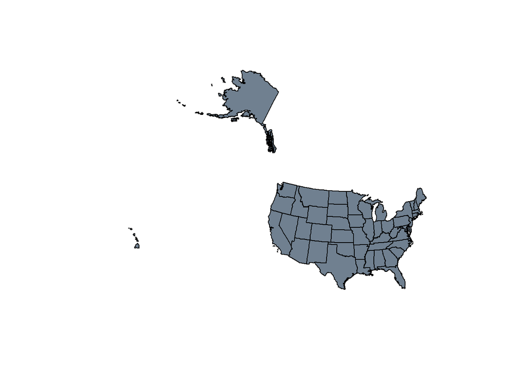

```r
#plot the state boundaries file
  plot(stateboundaries, col="slategray")
```

```r
#report the first few records of places
  head(places)
```

```
##             coordinates AREA PERIMETER PLACES_ PLACES_ID    AREANAME CLASS
## 1 (973627.7, -932121.6)    0         0       0         1   Abbeville  city
## 2 (797273.8, -713583.2)    0         0       0         2  Adamsville  city
## 3   (771384, -645200.3)    0         0       0         3     Addison  town
## 4   (735901.9, -803340)    0         0       0         4       Akron  town
## 5 (813152.8, -755248.5)    0         0       0         5   Alabaster  city
## 6 (855032.8, -629628.5)    0         0       0         6 Albertville  city
##   ST STFIPS PLACECEN PLACEFIP HOUSEUNITS POPULATION POP_CL AREALAND
## 1 AL      1        5    00124       1320       3173      5   15.563
## 2 AL      1       10    00460       1554       4161      5    3.069
## 3 AL      1       15    00484        286        626      3    2.968
## 4 AL      1       20    00676        220        468      2    0.555
## 5 AL      1       25    00820       5144      14732      6   18.846
## 6 AL      1       30    00988       6238      14507      6   25.511
##   AREAWATER F_POLYGONID F_SCALE F_ANGLE
## 1     0.047           0       1       0
## 2     0.000           0       1       0
## 3     0.000           0       1       0
## 4     0.000           0       1       0
## 5     0.041           0       1       0
## 6     0.100           0       1       0
```

# 6 Connecting to Microsoft Access 32-bit from R 64-bit

(without an odbc named connection)

Example of getting 32-bit Access data into 64-bit R that you can write into a script so that you don’t need to do the steps manually. You do need to have 32-bit R available on your machine for this to run, and this script assumes a default location for the 32 bit R, so adjust as needed. The first code part goes into your main script, the second code part is the entire contents of a little R script file that you create and is called (sourced) from the main script, this combination extracts and saves and then loads the data from the access database without having to switch between R versions.

This code chunk goes in the main script that will be execulted using 64-bit R

```r
## Lots of script above here
## set the 32-bit script location
  pathIn32BitRScript <- "C:/NAZRUG/GetAccessDbTables.R"

## run the 32 bit script
  system(paste0(Sys.getenv("R_HOME"), "/bin/i386/Rscript.exe ",pathIn32BitRScript))

## Set the path for loading the rda files created from the little script
  pathOutUpAccdb <- "C/NAZRUG/"

## load the tables just created from that script
  load(paste0(pathOutUpAccdb,"customers.rda"))
  load(paste0(pathOutUpAccdb,"vehicles.rda"))

## Processing steps below here
```

```r
library(RODBC)
#set the database path
  accessdb <- "C:\\NAZRUG\\MikeGarage.accdb"

#connect to the database
  accesscon <- odbcConnectAccess2007(accessdb)

#fetch the tables from the database. Modify the as-is and string settings as desired
  customers <- sqlFetch (accesscon,"Customers",as.is=FALSE, stringsAsFactors = FALSE)
  vehicles <- sqlFetch(accesscon,"Vehicles",as.is=FALSE, stringsAsFactors = FALSE)

#save the tables
  save(customers, file = "C\\NAZRUG\\customers.rda")
  save(vehicles, file = "C:\\NAZRUG\\vehicles.rda")

#close the connection to the db
  close(accesscon)
```

# 7 Creating a named ODBC connection to a SQL Server DB

I am not clear on exactly when this is necessary, but we have used this successfully when we do not have SQL Server installed on a machine and want to access data in a SQL Server DB.

This applies to 32-bit.

Select **Start**, search for and run *“odbcad32.exe”*.

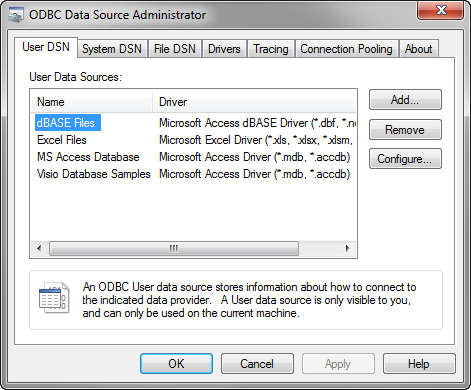

Select **Add**.

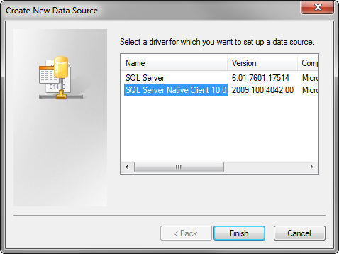

Select *SQL Server Native Client 10.0* for SQL Server 2008, or *SQL Server Native Client 11.0* for SQL Server 2014, and then select **Finished**.

[figure not shown]

Fill in a name (this is what you will call it by from R).  
Give the connection a description.  
Point to the SQL Server you wish to use.

[figure not shown]

Leave these as the default unless you need to change them.

[figure not shown]

Select your database from the drop down for **Change the default database to:**.

[figure not shown]

Leave these as the default unless you need to change them and select **Finish**.

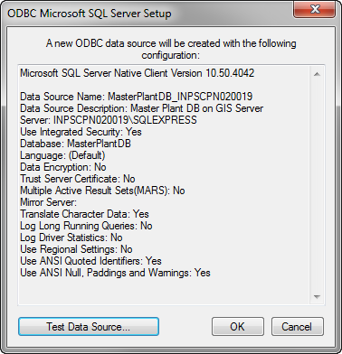

A result window will pop up showing you the parameters of the connection.

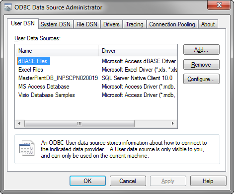

This connection will now appear in the ODBC Data Source Administrator.

Select **OK**.